# Dataset Intersections

2024-12-03

2024/12/02: Now unlike the way I did it in the big combined script, here I am going to try out doing more stringent FDR cutoffs as well as fairly relaxed log2FC cutoffs. I may also change the methylation list input, in fact I probably should (either use limma with cbioportal or confirm results from the probe-wise version).

# Comparing and filtering A1, TE, TM, and A2 to generate “linked genes” and “linked persistent genes” lists

## Reading in datasets to intersect

```r
GSE63127_CS_NS_GEO2R_limma <- read.table("../2_Outputs/1_Airway_DEGs/GSE63127_CS_NS_limma_20241204.txt", header = TRUE)

DGE_LUAD_T_NM_DESeq2 <- read.table("../2_Outputs/4_Tumor_DEGs/TE_T_NM_DEseq2_DEGs_20241204.txt")

TCGA_LUAD_limma_DMG <- read.table("../2_Outputs/5_Tumor_DMGs/TCGA_LUAD_limma_DMG_20241203.txt")

GSE7895_persistent_DEGs <- read.table("../2_Outputs/1_Airway_DEGs/GSE7895_persistent_DEGs_20241127.txt")
```

# I. Using more stringent FDR cutoffs

## I.i Applying FDR cutoffs

```r
library(dplyr)
### Testing FDR and log2FC cutoffs ###

# A1 DEGs
FDR_cutoff_A1=0.001
log2FC_cutoff_A1=0.5
nrow(GSE63127_CS_NS_GEO2R_limma[GSE63127_CS_NS_GEO2R_limma$adj.P.Val<FDR_cutoff_A1
                                    & abs(GSE63127_CS_NS_GEO2R_limma$logFC)>log2FC_cutoff_A1,])
```

```
## [1] 703
```

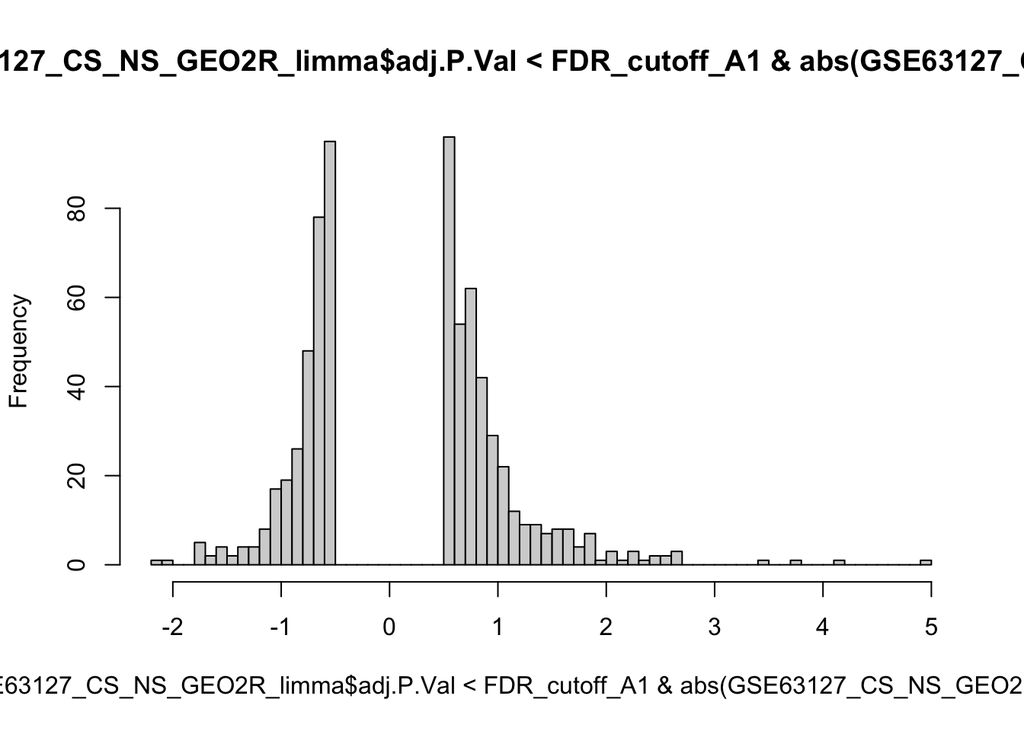

```r
hist(GSE63127_CS_NS_GEO2R_limma[GSE63127_CS_NS_GEO2R_limma$adj.P.Val<FDR_cutoff_A1
                                    & abs(GSE63127_CS_NS_GEO2R_limma$logFC)>log2FC_cutoff_A1,]$logFC, breaks = 100)
```

```r
# TCGA-LUAD DEGs
FDR_cutoff_TE=0.001
log2FC_cutoff_TE = 1.5

nrow(DGE_LUAD_T_NM_DESeq2[DGE_LUAD_T_NM_DESeq2$FDR<FDR_cutoff_TE
                              & abs(DGE_LUAD_T_NM_DESeq2$log2FC)>log2FC_cutoff_TE,])
```

```
## [1] 2571
```

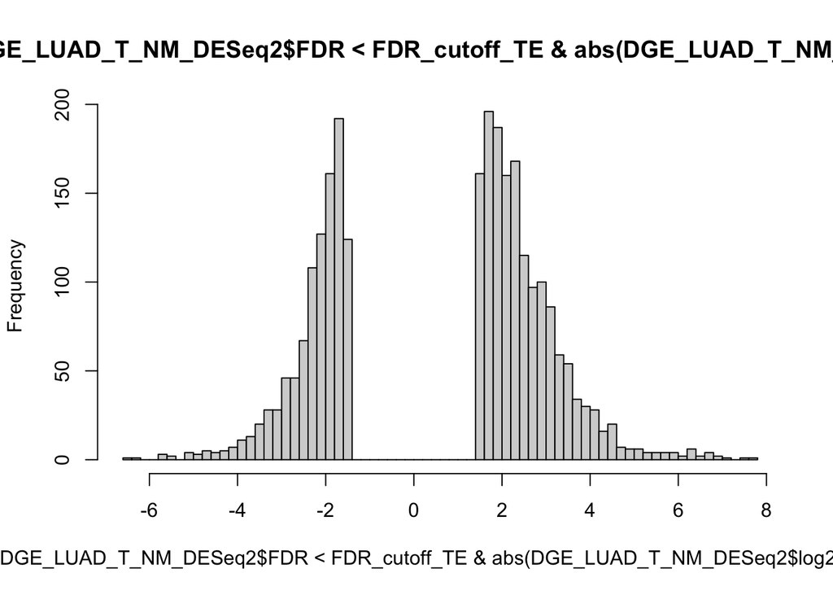

```r
hist(DGE_LUAD_T_NM_DESeq2[DGE_LUAD_T_NM_DESeq2$FDR<FDR_cutoff_TE
                              & abs(DGE_LUAD_T_NM_DESeq2$log2FC)>log2FC_cutoff_TE,]$log2FC, breaks = 100)
```

```r
# TCGA-LUAD DMGs limma

FDR_cutoff_TM=0.001
log2FC_cutoff_TM = 0.5
nrow(TCGA_LUAD_limma_DMG[TCGA_LUAD_limma_DMG$FDR<FDR_cutoff_TM
                               & abs(TCGA_LUAD_limma_DMG$log2FC)>log2FC_cutoff_TM,])
```

```
## [1] 3746
```

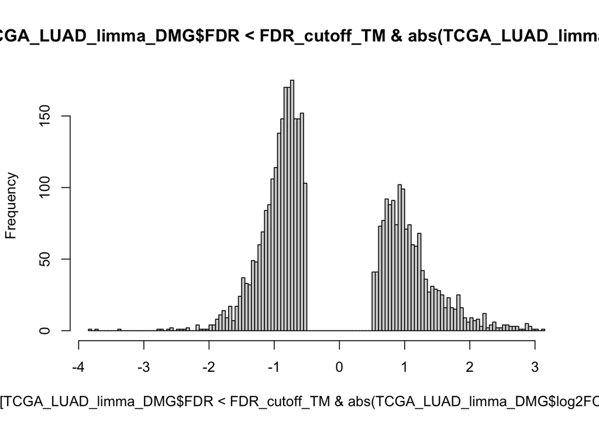

```r
hist(TCGA_LUAD_limma_DMG[TCGA_LUAD_limma_DMG$FDR<FDR_cutoff_TM
                               & abs(TCGA_LUAD_limma_DMG$log2FC)>log2FC_cutoff_TM,]$log2FC, breaks = 100)
```

```r
### Applying log2FC cutoffs and formatting consistently for merge ###

GSE63127_CS_NS_GEO2R_limma_cutoff <- GSE63127_CS_NS_GEO2R_limma %>%
  filter(abs(logFC)>log2FC_cutoff_A1) %>%
  filter(adj.P.Val < FDR_cutoff_A1) %>%
  dplyr::rename(., Gene = Gene.symbol, FDR_A1 = adj.P.Val, log2FC_A1 = logFC) %>%
  dplyr::select(., Gene, FDR_A1, log2FC_A1)

DGE_LUAD_T_NM_DESeq2_cutoff <- DGE_LUAD_T_NM_DESeq2 %>%
  filter(abs(log2FC)>log2FC_cutoff_TE) %>%
  filter(FDR < FDR_cutoff_TE) %>%
  dplyr::rename(., FDR_TE = FDR, log2FC_TE = log2FC, Gene = gene) %>%
  dplyr::select(., Gene, FDR_TE, log2FC_TE)

TCGA_LUAD_limma_DMG_cutoff <- TCGA_LUAD_limma_DMG %>%
  filter(abs(log2FC)>log2FC_cutoff_TM) %>%
  filter(FDR < FDR_cutoff_TM) %>%
  dplyr::rename(., FDR_TM = FDR, log2FC_TM = log2FC) %>%
  dplyr::select(., Gene, FDR_TM, log2FC_TM)
```

### I.ii Intersection of A1 and TE DEGs

```r
## Merge the lists

A1_TE_merged_DEGs <- GSE63127_CS_NS_GEO2R_limma_cutoff %>%
  inner_join(., DGE_LUAD_T_NM_DESeq2_cutoff, by = "Gene") %>%
  filter(sign(log2FC_A1)==sign(log2FC_TE)) # Filter to genes with same signs

nrow(A1_TE_merged_DEGs)
```

```
## [1] 107
```

### I.iii Intersection of A1/TE DEGs with TM DMGs

```r
## Merge the lists

## Using the limma derived DMGs instead
A1_TE_TM_linked_genes <- A1_TE_merged_DEGs %>%
  inner_join(., TCGA_LUAD_limma_DMG_cutoff, by = "Gene") %>%
  filter(sign(log2FC_A1)!=sign(log2FC_TM)) # Filter to genes with opposite sign

nrow(A1_TE_TM_linked_genes)
```

```
## [1] 29
```

### I.iv.1 Visualizing Spearman correlations of log2FC values

```r
## Visualizing Spearman correlations
library(GGally)
```

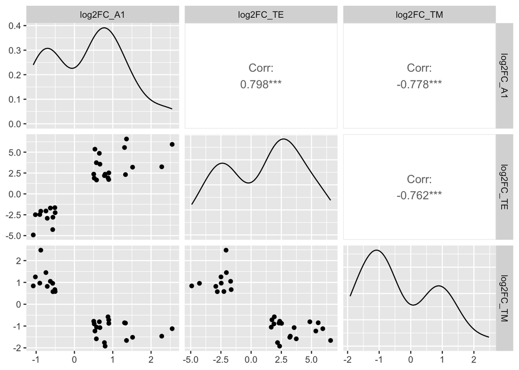

```r
ggpairs(A1_TE_TM_linked_genes[, c("log2FC_A1", "log2FC_TE", "log2FC_TM")],
  upper = list(continuous = wrap("cor", method = "spearman")),
  lower = list(continuous = "points", combo = "facethist", discrete = "facetbar", na ="na"),
  diag = list(continuous = "densityDiag", discrete = "barDiag", na = "naDiag"))
```

### I.iv.2 Visualizing multiple linear regression of the log2FC values

```r
mlr_airway_model <- lm(log2FC_A1 ~ log2FC_TE + log2FC_TM, data = A1_TE_TM_linked_genes)
summary(mlr_airway_model)
```

```
##
## Call:
## lm(formula = log2FC_A1 ~ log2FC_TE + log2FC_TM, data = A1_TE_TM_linked_genes)
##
## Residuals:
##      Min       1Q   Median       3Q      Max
## -0.83281 -0.26627 -0.06755  0.17305  1.18893
##
## Coefficients:
##             Estimate Std. Error t value Pr(>|t|)
## (Intercept)  0.08187    0.09042   0.905  0.37353
## log2FC_TE    0.16716    0.04956   3.373  0.00234 **
## log2FC_TM   -0.31750    0.13873  -2.289  0.03048 *
## ---
## Signif. codes:  0 '***' 0.001 '**' 0.01 '*' 0.05 '.' 0.1 ' ' 1
##
## Residual standard error: 0.4619 on 26 degrees of freedom
## Multiple R-squared:  0.801,  Adjusted R-squared:  0.7856
## F-statistic: 52.31 on 2 and 26 DF,  p-value: 7.699e-10
```

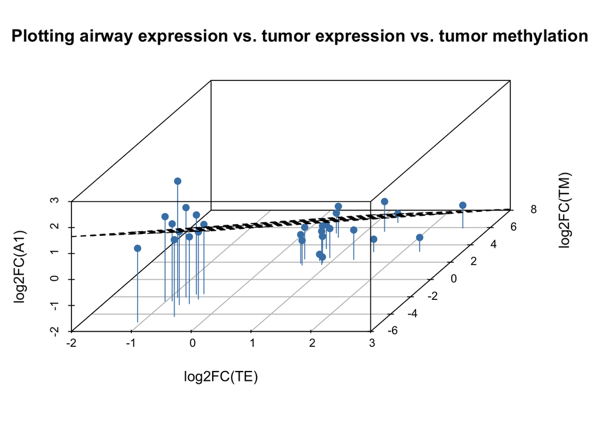

```r
library(scatterplot3d)
s3d <- scatterplot3d(x = A1_TE_TM_linked_genes$log2FC_A1,
              y = A1_TE_TM_linked_genes$log2FC_TE,
              z = A1_TE_TM_linked_genes$log2FC_TM,
              main="Plotting airway expression vs. tumor expression vs. tumor methylation",
              xlab = "log2FC(TE)",
              ylab = "log2FC(TM)",
              zlab = "log2FC(A1)",
              pch = 19,
              #color = colors_3d, # getting color values from methylation sign
              color = "steelblue",
              labels = A1_TE_TM_linked_genes$Gene,
              type = "h",
              #highlight.3d = TRUE,
              angle = 60
              )
s3d$plane3d(mlr_airway_model) # Add a plane based on the multiple linear regression model
```

OK here is an amazing interaction network I got:

https://version-12-0.string-db.org/cgi/network?networkId=bK3IJNEMHJEy

This was using the 29 genes given by the parameters:

FDR_cutoff_A1=0.001 log2FC_cutoff_A1=0.5

FDR_cutoff_TE=0.001 log2FC_cutoff_TE = 1.5

FDR_cutoff_TM=0.001 log2FC_cutoff_TM = 0.5

Now to check via intersection with the “persistent” genes:

## 5.3 Comparing and filtering A2 and “linked” genes to give “persistent linked genes”

### 5.3.1 Applying cutoffs

```r
# For now, no cutoffs
```

### 5.3.2 Filtering by dataset intersection

```r
A1_TE_TM_A2_persistent_linked_genes <- A1_TE_TM_linked_genes %>%
  dplyr::inner_join(., GSE7895_persistent_DEGs, by = "Gene") %>%
  dplyr::filter(sign(log2FC_A1) == sign(CS_NS_A2)) # Ensure signs are the same between A1 and A2 CS vs NS

nrow(A1_TE_TM_A2_persistent_linked_genes)
```

```
## [1] 4
```

```r
A1_TE_TM_A2_persistent_linked_genes
```

```
##      Gene       FDR_A1 log2FC_A1       FDR_TE log2FC_TE       FDR_TM  log2FC_TM
## 1 CEACAM6 5.102659e-22 0.8945448 4.021570e-12  1.721725 7.388283e-06 -0.7157472
## 2    GPX2 1.654570e-45 2.5506583 1.570672e-47  5.933983 6.039099e-05 -1.1208355
## 3    NQO1 5.660885e-42 1.5172869 5.694570e-34  3.201066 1.208337e-13 -1.5153198
## 4   S100P 3.017522e-10 0.6501092 4.170991e-40  4.862296 1.645764e-04 -0.8043111
##    CS_NS_A2  FS_NS_A2  CS_FS_A2       FDR_A2
## 1 0.9338987 0.6059897 0.3279090 5.320093e-06
## 2 2.9950716 1.5416876 1.4533840 8.082128e-17
## 3 2.0600457 0.9921077 1.0679380 8.749025e-18
## 4 0.8341189 0.6625807 0.1715382 7.117128e-05
```

### 5.3.3 Additional checks (correlation of log2FCs in A1 and A2)

```r
cor.test(A1_TE_TM_A2_persistent_linked_genes$log2FC_A1, y = A1_TE_TM_A2_persistent_linked_genes$CS_NS_A2, use = "everything",
    method = "spearman")
```

```
##
##  Spearman's rank correlation rho
##
## data:  A1_TE_TM_A2_persistent_linked_genes$log2FC_A1 and A1_TE_TM_A2_persistent_linked_genes$CS_NS_A2
## S = 0, p-value = 0.08333
## alternative hypothesis: true rho is not equal to 0
## sample estimates:
## rho
##   1
```

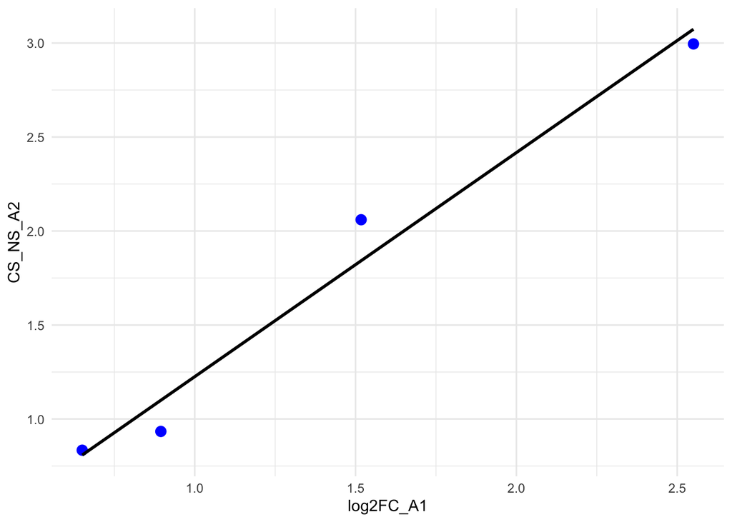

```r
ggplot(A1_TE_TM_A2_persistent_linked_genes, aes(x = log2FC_A1, y = CS_NS_A2)) +
  geom_point(color = "blue", size = 3) +                # Scatter points
  geom_smooth(method = "lm", se = FALSE, color = "black") + # Add a trend line +
  theme_minimal()
```

## Save outputs

```r
# write.table(A1_TE_TM_linked_genes, "../2_Outputs/6_Linked_genes/A1_TE_TM_linked_genes_20241204.txt")
#
# write.table(A1_TE_TM_A2_persistent_linked_genes, "../2_Outputs/6_Linked_genes/A1_TE_TM_A2_persistent_linked_genes_20241204.txt")
```